# Two Variables: Quantitative and Qualitative

Author

Shapple Kate Anne A. Nicolas

Published

November 14, 2026

# The Data

```r
# install packages: install.packages("package")
# load packages
library(tidyverse)
library(knitr)
library(gtsummary)
library(ggstatsplot)
library(downlit)
library(broom)
library(here)
#library(car)
```

```r
# load the data
df <- read_csv(here("data", "My_Data.csv"))

df <- df |>
  mutate(
    internet_source = factor(internet_source),
    study_hours_num = case_when(
      study_hours == "Less than 5 hours" ~ 3,
      study_hours == "5 to 10 hours" ~ 7.5,
      study_hours == "More than 10 hours" ~ 12,
      TRUE ~ 5
    )
  ) |>
  select(
    study_hours_num,
    study_hours,
    internet_source
  )
```

The `NVSU_Student_Survey` data set is a data frame with 68 rows and 2 main variables.

- `study_hours`: Less than 5 hours, 5 to 10 hours, More than 10 hours (converted to numeric values for analysis).
- `internet_source`: Fixed Wi-Fi / Broadband / Campus Wi-Fi, Mobile Data / Cellular.

This data set provides information on student study habits and internet connectivity sources at Nueva Vizcaya State University (NVSU). The first 6 rows of the data set are shown in Table 1.

```r
df |>
  head() |> # getting the first six rows of the data
  kable(
    col.names = c("Study Hours (Numeric)", "Study Hours (Category)", "Internet Source")
  ) # creating a table
```

Table 1: The first 6 observations of the data set.

| Study Hours (Numeric) | Study Hours (Category) | Internet Source |
| --- | --- | --- |
| 3.0 | Less than 5 hours | Fixed Wi-Fi / Broadband / Campus Wi-Fi |
| 7.5 | 5 to 10 hours | Fixed Wi-Fi / Broadband / Campus Wi-Fi |
| 7.5 | 5 to 10 hours | Fixed Wi-Fi / Broadband / Campus Wi-Fi |
| 3.0 | Less than 5 hours | Mobile Data / Cellular |
| 12.0 | More than 10 hours | Fixed Wi-Fi / Broadband / Campus Wi-Fi |
| 12.0 | More than 10 hours | Mobile Data / Cellular |

## Descriptive Statistics

The summary statistics of study_hours_num when grouped according to internet_source are shown in Table 2.

```r
df |>
  tbl_summary(
    by = internet_source,
    include = study_hours_num,
    statistic = list(all_continuous() ~ "{mean} ({sd})"),
    label = list(study_hours_num ~ "Estimated Study Hours")
  ) |>
  add_overall()
```

Table 2: Summary statistics of study hours grouped by internet source.

| **Characteristic** | **Overall** N = 68<sup>1</sup> | **Fixed Wi-Fi / Broadband / Campus Wi-Fi** N = 37<sup>1</sup> | **Mobile Data / Cellular** N = 31<sup>1</sup> |
| --- | --- | --- | --- |
| Estimated Study Hours |  |  |  |
| 3 | 12 (18%) | 8 (22%) | 4 (13%) |
| 7.5 | 37 (54%) | 23 (62%) | 14 (45%) |
| 12 | 19 (28%) | 6 (16%) | 13 (42%) |

<sup>1</sup> n (%)

# Hypothesis Testing

### Research Question

Do students using fixed broadband versus mobile data differ significantly in their estimated weekly study hours?

### Hypothesis and Test Statistics

- $H_0:\mu_A=\mu_M$; The distribution of weekly study hours is identical across internet source groups.
- $H_a:\mu_A\ne\mu_M$; Weekly study hours differ significantly between internet source groups.
- Significance level, $\alpha=5\%\,\text{or p-value}\,\le\,0.05$.
- **Mann-Whitney $U$ test (non-parametric numerical-categorical test).**

```r
car::leveneTest(study_hours_num ~ internet_source, data = df, center = mean) |>
  tidy() |>
  mutate(across(where(is.numeric), ~ round(.x, 2))) |>
  kable()
```

Table 3: Levene’s test for homogeneity of variance.

| statistic | p.value | df | df.residual |
| --- | --- | --- | --- |
| 3.47 | 0.07 | 1 | 66 |

```r
df_fixed <- df |>
  filter(internet_source == "Fixed Wi-Fi / Broadband / Campus Wi-Fi") |>
  select(study_hours_num)

shapiro_fixed <- shapiro.test(df_fixed$study_hours_num) |>
  tidy() |>
  mutate(across(where(is.numeric), ~ round(.x, 2)))

df_mobile <- df |>
  filter(internet_source == "Mobile Data / Cellular") |>
  select(study_hours_num)

shapiro_mobile <- shapiro.test(df_mobile$study_hours_num) |>
  tidy() |>
  mutate(across(where(is.numeric), ~ round(.x, 2)))

bind_rows(shapiro_fixed, shapiro_mobile) |>
  mutate(
    internet_source_group = c("Fixed Wi-Fi / Broadband", "Mobile Data / Cellular")
  ) |>
  relocate(internet_source_group, .before = 1) |>
  kable()
```

Table 4: Shapiro-Wilk normality test.

| internet_source_group | statistic | p.value | method |
| --- | --- | --- | --- |
| Fixed Wi-Fi / Broadband | 0.78 | 0 | Shapiro-Wilk normality test |
| Mobile Data / Cellular | 0.78 | 0 | Shapiro-Wilk normality test |

### Results and Interpretation

The plot and test statistics is shown on Figure 1.

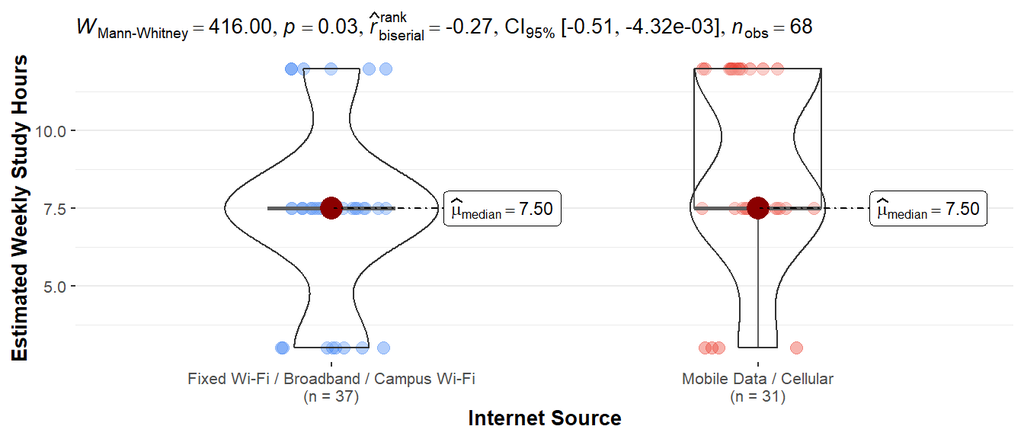

Figure 1: Comparison of study hours by internet source.

```r
ggbetweenstats(
  data = df,
  x = internet_source,
  y = study_hours_num,
  type = "nonparametric",
  bf.message = FALSE,
  xlab = "Internet Source",
  ylab = "Estimated Weekly Study Hours"
)
```